# Exclusions and Attendance

How much of the attendance problem is exclusion — and if not that, then what? A secondary analysis alongside *How to Pull the Right Lever*.

Author

Affiliation

Adam Dennett

Bartlett Centre for Advanced Spatial Analysis, University College London

Published

October 23, 2026

**ImportantThe question**

Brighton & Hove’s council has begun asking how exclusions from secondary schools work in the city. *How to Pull the Right Lever* found that attendance is the single largest school-level driver of GCSE attainment, so an interest in exclusions is a reasonable thing to follow from it: excluded pupils are not in school, and a pupil not in school does not learn.

The question this note answers is narrower and more useful. **Of the attendance problem that exists, how much of it is exclusion?** If the answer is “most of it”, exclusions policy is attendance policy and the council should act. If the answer is “a few per cent”, then pressing schools on exclusions is a cheap substitute for the harder work, and risks moving the only lever a school fully controls in a direction that helps nobody.

# 1 The short answer

In 2025/26, across every state-funded secondary school in England:

- Absence ran at **8.01%** of possible sessions.
- Sessions missed because a pupil was suspended accounted for **0.251 percentage points** of that — **3.1% of all absence**.
- Illness accounted for **45.9%** and unauthorised absence with no given reason for **29.4%**.

If every suspension in England stopped tomorrow and none of those pupils missed a single further session, the secondary absence rate would fall from 8.01% to 7.76%. That is the entire size of the prize, and it is an upper bound rather than an estimate, because it assumes a pupil who is no longer suspended attends perfectly instead.

**NoteVerdict**

**Exclusions are a real but small part of the attendance story, and they are a symptom of it rather than a cause of it.**

They are not a red herring — the association between a school’s suspension rate and its attendance is strong and worth understanding. But the association runs overwhelmingly through *the same pupils*, not through the suspensions themselves: schools that suspend more have more absence of **every** kind, including the kinds suspension cannot touch. Treating exclusions as the attendance lever would be acting on the symptom that is easiest to count and easiest to blame a school for.

For Brighton & Hove specifically the case is weaker still. The city suspends **less** than most of England and has close to the **worst** attendance in the country. Whatever is driving absence here, it is not how often the schools suspend.

**ImportantAnd there is a much better question in the same file**

The absence file splits every missed session by register code, so the city’s excess absence can be decomposed exactly. Doing that (§7) turns up something far more useful than anything in the exclusions data:

- Brighton & Hove’s secondary absence runs **1.83 percentage points** above England’s.
- **Illness accounts for 95% of that gap.** The city is **2nd worst of 150** local authorities on illness-coded absence, and **65th** — mid-table — on unauthorised absence.
- Suspension’s contribution to the gap is **negative**.

Every one of the city’s ten secondaries is above the English illness rate, the gap predates the pandemic and has roughly tripled since, and it is far larger than the city’s disadvantage predicts. **That is where the attendance problem is.**

# 2 What the data is

Three published sources, all Open Government Licence v3.0, assembled by [`R/15_exclusions.R`](https://github.com/adamdennett/school_attainment_tool/blob/main/R/15_exclusions.R).

Table 1

| Source | What it gives | Coverage |
| --- | --- | --- |
| Pupil absence in schools in England (school level, autumn + spring) | Sessions missed, split by register code — including code E, *excluded, no alternative provision made* | 2016/17 to 2025/26 |
| Suspensions and permanent exclusions in England (school level) | Headcount, suspensions, permanent exclusions, and pupils receiving one or more suspension | 2006/07 to 2024/25 |
| This project’s school characteristics panel | Attainment 8, disadvantage, EAL, SEN and full-year absence, as used throughout *Pulling the Right Lever* | 2021/22 to 2024/25 |

Three things about this are worth saying plainly before any number is quoted.

**Absence here is autumn and spring terms only.** That is the basis the DfE publishes early enough to reach 2025/26, and it is the basis used in the 2025/26 addendum to the main report, so the two agree. Summer-term absence is excluded for every year equally.

**The exclusions collection runs a year behind.** Suspensions for 2025/26 are not published until summer 2027. Everything joining exclusions to absence therefore stops at 2024/25; the absence decomposition alone runs to 2025/26.

**Code E is measured from the attendance register, not inferred.** The central number in this note — how many sessions suspension actually costs — is not derived by multiplying suspensions by an assumed length. It is a column in the published absence file, counted by schools as they mark the register. 3,419 secondary schools report it.

# 3 How big is exclusion, as a share of absence?

## 3.1 Every reason, ranked

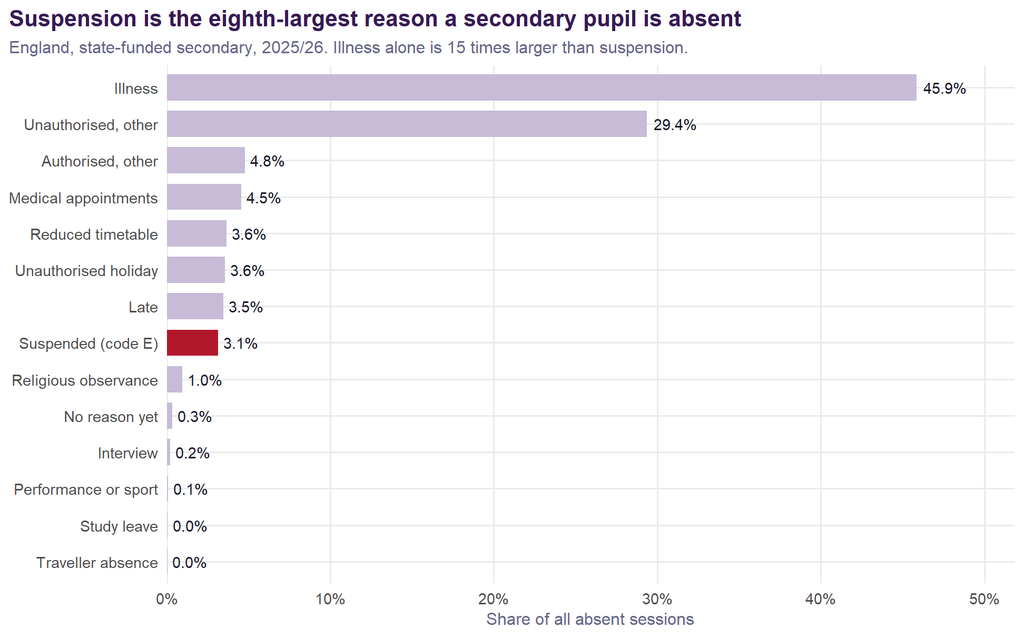

Figure 1: Secondary absence in England by register code, 2025/26, autumn and spring terms. Code E — suspension — is highlighted.

Illness is the mountain. “Unauthorised, other” — the code that carries most persistent absence — is the second mountain. Suspension is the 8th largest reason a secondary pupil in England is not in a lesson, behind being late and behind unauthorised family holidays.

## 3.2 And it has grown

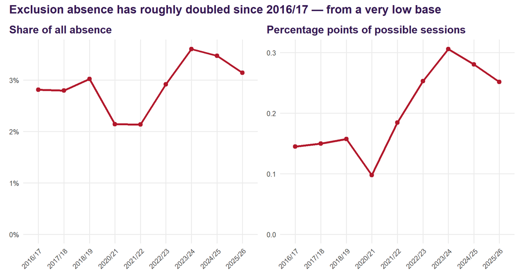

Figure 2: Suspension’s contribution to secondary absence, England, autumn and spring terms. Left: as a share of all absence. Right: in percentage points of possible sessions. 2019/20 is absent from the published series.

This is the honest part of the case for taking exclusions seriously. Suspension’s contribution to absence has gone from 0.145 percentage points in 2016/17 to 0.251 in 2025/26, and England’s suspension rate has risen from 9.3 per 100 pupils to 21.3. Something real is happening in school behaviour policy.

But the scale has not changed. Doubling a figure that was 2.8% of absence gets you to 3.1% of absence.

## 3.3 And nationally, it has risen while attendance improved

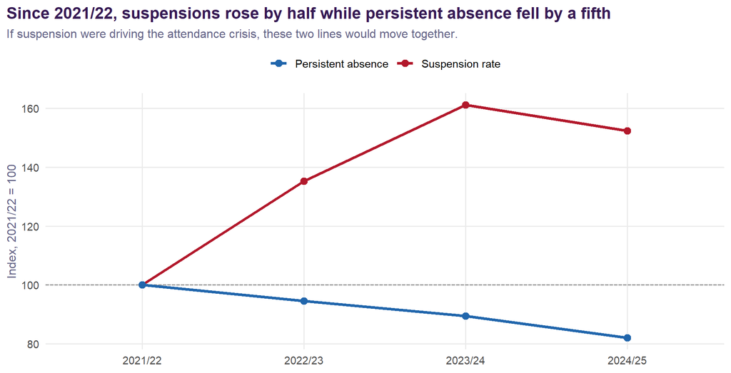

Figure 3: Suspension rate against persistent absence, England secondary, indexed to 2021/22 = 100. The exclusions series stops a year earlier than absence.

Over the four years for which both series exist, England’s secondary suspension rate rose by about half while persistent absence fell by about a fifth. That is not proof that suspensions do not matter — both series are moved by other things, and the post-COVID attendance recovery is doing most of the work on the blue line. But it is the opposite of what you would see if exclusions were the engine of the attendance problem, and anyone proposing that they are has to account for it.

# 4 Does a school that suspends more have worse attendance?

Yes, strongly. This is the finding that makes the council’s interest reasonable, and it deserves to be stated at full strength before it is taken apart.

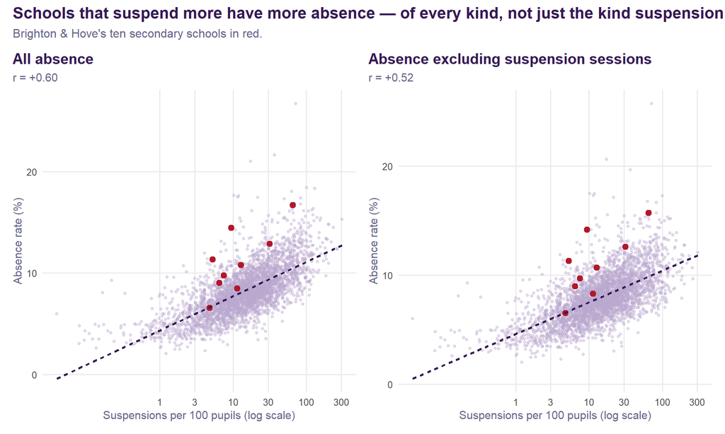

Figure 4: Every state-funded secondary school in England with at least 100 on roll, 2024/25. Left: headline absence. Right: absence with every suspension session removed.

The right-hand panel is the whole argument. It removes every single session that a suspension caused, and the relationship barely moves: from r = +0.60 to r = +0.52.

A school that suspends a lot is a school where a lot of pupils are absent for reasons that have nothing to do with being suspended. The suspension rate is **telling you about the pupils, not doing something to them**.

## 4.1 What survives a control for intake

Table 2

| Specification | Extra absence per suspension per 100 pupils (pp) | t | R² | School-years |
| --- | --- | --- | --- | --- |
| Raw | +0.0432 | 64 | 0.240 | 12,876 |
| + disadvantage | +0.0356 | 51 | 0.292 | 12,876 |
| + disadvantage, EAL, SEN, year | +0.0266 | 41 | 0.460 | 12,876 |
| + school fixed effects | +0.0124 | 15 | 0.876 | 12,048 |

Each row adds a control. The outcome throughout is **absence with suspension sessions already removed**, so nothing here is mechanical.

The last row is the one that matters. It carries a separate intercept for every school, so it no longer compares a school in Blackpool with a school in Surrey. It asks: when a school suspends more *than it usually does*, does it also have worse attendance *than it usually does*? That differences away everything fixed about the intake, the catchment, the building and the leadership.

The answer is yes, and it is **29% the size of the raw association**. 71% of what the scatter plot shows is schools being different from each other, not suspension doing anything.

**TipWhat that coefficient means in practice**

A school that raises its suspension rate by 10 per 100 pupils — a large move, well beyond what most schools do in a year — is associated with **0.12 percentage points** more non-suspension absence. Against a mean absence rate of around 8.0%.

And even that is an association, not an effect. The plausible mechanism runs the other way: a pupil who has disengaged both stops attending and gets suspended, and a school whose cohort is unravelling does more of both in the same year.

# 5 Does any of this reach attainment?

This is the step the council’s theory needs. *Pulling the Right Lever* established that absence is the largest school-level predictor of GCSE attainment. If exclusions matter to attainment, they should add something to that model.

Table 3

| Model | R² | School-years |
| --- | --- | --- |
| Intake only (disadvantage, EAL) | 0.4655 | 12,818 |
| Intake + absence | 0.6234 | 12,818 |
| Intake + suspension rate | 0.5146 | 12,818 |
| Intake + absence + suspension rate | 0.6279 | 12,818 |
| Absence added on top of suspension | 0.1133 | 12,818 |
| Suspension added on top of absence | 0.0046 | 12,818 |

Read the last two rows as the test:

- Starting from a model that already has the suspension rate in it, **adding absence raises R² by 0.113**.
- Starting from a model that already has absence in it, **adding the suspension rate raises R² by 0.005**.

Absence does about **25 times as much work** as suspension in explaining what a school’s cohort gets at GCSE. Suspension is not worthless — the coefficient is negative and statistically significant on 12,000-odd school-years, as almost anything is at that sample size — but once you know a school’s absence rate, knowing how often it suspends tells you very nearly nothing further.

# 6 Brighton & Hove

## 6.1 The city suspends below average and attends near the bottom

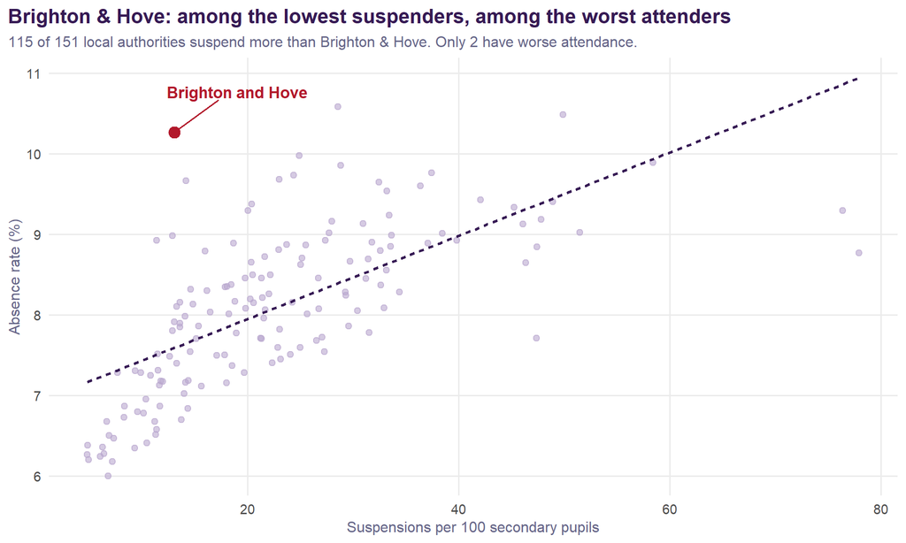

Figure 5: Local authorities with more than 2,000 secondary pupils, 2024/25. Brighton & Hove in red.

This is the finding that should settle the question locally.

In 2024/25 — the last year for which both series exist — Brighton & Hove was the **3rd worst** of 151 local authorities for secondary absence, at 10.27% against an England figure of 8.09%. (In 2025/26 it is 6th worst; the city moves about in the top handful from year to year.) On suspensions it ranks **116th** — meaning 115 local authorities suspend *more* than it does, and it sits comfortably in the lower half of the country at 13.0 suspensions per 100 pupils against England’s 21.3.

Exclusion sessions account for 0.173 percentage points of the city’s 10.27% absence rate — about **1.7% of it**, lower than the national share of 3.1%.

A city that suspends less than most of England and attends worse than almost all of it does not have an exclusions-driven attendance problem. It has an attendance problem.

## 6.2 Permanent exclusion is close to extinct here

Table 4

| Year | Suspensions per 100 | England | Permanent exclusions | Absence (%) | England | of which suspension (pp) | Persistent absence (%) |
| --- | --- | --- | --- | --- | --- | --- | --- |
| 2016/17 | 12.0 | 9.3 | 17 | 5.96 | 5.14 | 0.157 | 15.0 |
| 2017/18 | 11.0 | 10.1 | 10 | 6.05 | 5.36 | 0.131 | 15.2 |
| 2018/19 | 9.4 | 10.7 | 5 | 5.90 | 5.20 | 0.114 | 13.7 |
| 2020/21 | 8.7 | 8.5 | 4 | 4.81 | 4.56 | 0.079 | 12.0 |
| 2021/22 | 9.5 | 14.0 | 4 | 10.12 | 8.64 | 0.100 | 31.3 |
| 2022/23 | 9.6 | 18.9 | 2 | 9.90 | 8.67 | 0.088 | 28.7 |
| 2023/24 | 12.4 | 22.6 | 0 | 10.11 | 8.49 | 0.155 | 28.2 |
| 2024/25 | 13.0 | 21.3 | 1 | 10.27 | 8.09 | 0.173 | 27.2 |

Across ten secondary schools and roughly 12,800 pupils, the city permanently excluded 17 children in 2016/17, 4 in 2021/22, none at all in 2023/24, and 1 in 2024/25. Whatever problem the city has, it is not that its schools are permanently excluding children.

Note also the direction of travel. Between 2021/22 and 2024/25 the city’s suspension rate rose from 9.5 to 13.0 per 100 — and its persistent absence *fell*, from 31.3% to 27.2%. The two moved in opposite directions, here as nationally.

## 6.3 School by school

Table 5

| School | On roll | Susp. per 100 | Pupils suspended (%) | Perm. excl. | Absence (%) | of which susp. (pp) | Persistent absence (%) | Attainment 8 |
| --- | --- | --- | --- | --- | --- | --- | --- | --- |
| Longhill | 723 | 65.3 | 19.9 | 0 | 16.68 | 1.00 | 47.3 | 32.9 |
| Hove Park | 948 | 31.5 | 10.8 | 0 | 12.88 | 0.29 | 34.8 | 41.0 |
| Blatchington Mill | 1,635 | 12.8 | 6.4 | 0 | 10.78 | 0.10 | 30.8 | 50.8 |
| Cardinal Newman | 2,625 | 11.4 | 5.8 | 0 | 8.48 | 0.19 | 21.2 | 50.3 |
| Brighton Aldridge | 813 | 9.5 | 7.4 | 0 | 14.45 | 0.29 | 42.2 | 36.1 |
| Dorothy Stringer | 1,626 | 7.5 | 4.1 | 1 | 9.77 | 0.09 | 27.2 | 53.2 |
| Varndean | 1,497 | 6.5 | 4.3 | 0 | 9.03 | 0.06 | 20.6 | 48.8 |
| Portslade Aldridge | 928 | 5.3 | 3.1 | 0 | 11.34 | 0.06 | 26.1 | 42.5 |
| King’s | 903 | 4.8 | 3.1 | 0 | 6.56 | 0.05 | 15.4 | 53.6 |
| Patcham | 1,099 | 0.0 | 0.0 | 0 | 7.94 | 0.00 | 21.1 | 45.5 |

Three things stand out, and all three argue the same way.

**Longhill is the one school where the mechanical effect is visible at all.** It suspends far more than any other school in the city, and suspension costs it 1.00 percentage points of attendance. Against an absence rate of 16.7% and persistent absence at 47% of its pupils. Even at the city’s extreme, suspension is about 6% of the problem.

**Brighton Aldridge suspends below the city average and has the city’s second-worst attendance.** Its persistent absence is 42% of pupils on a suspension rate of 9.5 per 100 — a seventh of Longhill’s. The school with the best value added in the city, serving the most disadvantaged intake, is not solving its attendance problem by suspending, and is not causing it by suspending either.

**Patcham reports zero suspensions, four years running.** On a roll of about 1,100, in a school that recorded 193 suspensions in 2006/07. Four consecutive exact zeros is unusual enough that it may reflect recording practice as much as policy, and it would be worth the council asking — but taken at face value it is the cleanest possible test of the theory, and Patcham’s absence rate of 7.9% is good for the city without being exceptional.

# 7 If not exclusions, then what?

The same file that measures exclusion’s contribution measures every other reason a pupil is absent. So the question “which bit of the attendance problem is Brighton & Hove’s problem?” can be answered exactly, rather than guessed at.

## 7.1 The city’s excess absence, decomposed

Brighton & Hove’s secondary absence rate in 2025/26 was **9.84%** against England’s **8.01%** — an excess of **1.83 percentage points**.

Measured in percentage points of the same denominator, those gaps subtract cleanly, so the excess splits exactly by register code.

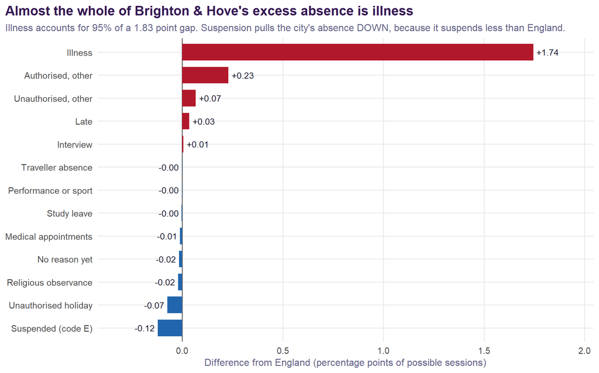

Figure 6: Brighton & Hove minus England, percentage points of possible sessions, 2025/26. Bars to the right are reasons the city has more absence than England; bars to the left, less.

Table 6

| Reason | B&H (pp) | England (pp) | Gap (pp) | Share of the city’s excess |
| --- | --- | --- | --- | --- |
| Illness | 5.418 | 3.674 | +1.744 | +95% |
| Authorised, other | 0.613 | 0.383 | +0.230 | +13% |
| Unauthorised, other | 2.420 | 2.353 | +0.067 | +4% |
| Late | 0.312 | 0.277 | +0.035 | +2% |
| Interview | 0.022 | 0.016 | +0.007 | +0% |
| Traveller absence | 0.000 | 0.002 | -0.002 | -0% |
| Performance or sport | 0.003 | 0.005 | -0.003 | -0% |
| Study leave | 0.000 | 0.003 | -0.003 | -0% |
| Medical appointments | 0.354 | 0.364 | -0.010 | -1% |
| No reason yet | 0.012 | 0.028 | -0.015 | -1% |
| Religious observance | 0.056 | 0.077 | -0.021 | -1% |
| Unauthorised holiday | 0.211 | 0.285 | -0.074 | -4% |
| Suspended (code E) | 0.130 | 0.251 | -0.122 | -7% |

**ImportantThe finding**

Of Brighton & Hove’s 1.83 percentage points of excess absence, **illness accounts for 1.74 points — 95% of the whole gap.**

Unauthorised absence with no given reason — truancy, in the everyday sense — accounts for 4% of it. The city is **ordinary** on that measure.

And suspension contributes **-0.12 points** — *negative*. Brighton & Hove suspends so much less than England that, on this one code, it has less absence than the country, not more. If its schools suspended at the national rate, the city’s absence would be **higher**.

## 7.2 Where the city ranks, code by code

Table 7

| Reason | B&H rate (pp) | Rank of 150 LAs (1 = worst) |
| --- | --- | --- |
| Authorised, other | 0.613 | 1 |
| Illness | 5.418 | 2 |
| All absence | 9.843 | 6 |
| Interview | 0.022 | 24 |
| Late | 0.312 | 53 |
| Reduced timetable | 0.292 | 55 |
| Unauthorised, other | 2.420 | 65 |
| Religious observance | 0.056 | 77 |
| Medical appointments | 0.354 | 80 |
| No reason yet | 0.012 | 104 |
| Unauthorised holiday | 0.211 | 114 |
| Suspended (code E) | 0.130 | 134 |

This is the table to put in front of anyone who wants to talk about exclusions.

The city is **2nd worst in England for illness-coded absence** and 1st worst on the catch-all authorised code. It is **65th of 150** on unauthorised absence — the middle of the country. And it is 134th on suspension — **133 local authorities lose more attendance to suspension than this one does.**

An authority looking at that list and choosing exclusions to investigate has picked the code it is 134th on, and left alone the one it is 2nd on.

## 7.3 It is not one school, and it is not new

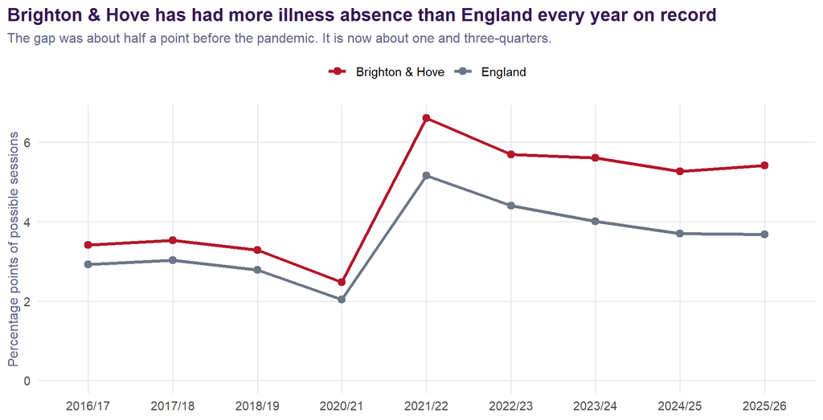

Figure 7: Illness-coded absence, Brighton & Hove against England, autumn and spring terms. 2019/20 is absent from the published series.

Table 8

| School | On roll | All absence (%) | Illness (pp) | Unauth., other (pp) | Auth., other (pp) | Suspension (pp) | Persistent absence (%) |
| --- | --- | --- | --- | --- | --- | --- | --- |
| Blatchington Mill | 1,680 | 10.69 | 6.20 | 2.40 | 0.50 | 0.08 | 27.4 |
| Longhill | 671 | 13.85 | 6.17 | 4.41 | 1.00 | 0.69 | 38.0 |
| Varndean | 1,521 | 8.90 | 5.95 | 1.21 | 0.60 | 0.09 | 20.6 |
| Dorothy Stringer | 1,690 | 10.51 | 5.75 | 2.70 | 1.17 | 0.09 | 27.0 |
| Brighton Aldridge | 705 | 13.27 | 5.73 | 5.41 | 0.51 | 0.18 | 39.0 |
| Portslade Aldridge | 943 | 9.63 | 5.14 | 2.53 | 0.33 | 0.06 | 24.4 |
| Patcham | 1,120 | 8.99 | 5.11 | 2.38 | 0.40 | 0.00 | 23.3 |
| King’s | 896 | 6.43 | 4.84 | 0.31 | 0.21 | 0.10 | 15.5 |
| Hove Park | 981 | 10.17 | 4.69 | 3.06 | 0.60 | 0.13 | 29.1 |
| Cardinal Newman | 1,872 | 8.76 | 4.59 | 2.12 | 0.58 | 0.16 | 21.7 |

**Every one of the city’s ten secondary schools has more illness-coded absence than the English average.** The lowest of them, Cardinal Newman, sits at 4.59 points against England’s 3.67. This is not a school problem that an inspection regime would find. It is a city-wide pattern.

It is also not a post-COVID artefact. The gap existed in 2016/17 — about 0.50 points — and has widened to 1.74. Something that was a modest standing feature of the city has become its defining attendance problem.

## 7.4 Is it just that the city is poorer?

No — and the reason is more interesting than a simple no.

Across local authorities, illness-coded absence runs **in the opposite direction to deprivation**. The more disadvantaged an authority, the *less* of its absence is recorded as illness and the *more* as unauthorised. Total absence barely moves.

Table 9

| Local authorities by disadvantage | Illness (pp) | Unauthorised, other (pp) | All absence (pp) |
| --- | --- | --- | --- |
| Least deprived quarter | 4.00 | 1.79 | 7.73 |
| 2nd quarter | 3.99 | 2.11 | 8.00 |
| 3rd quarter | 3.35 | 2.65 | 7.99 |
| Most deprived quarter | 3.01 | 3.26 | 8.35 |

That is a **social gradient in how the same behaviour gets recorded**, not a difference in how much school is missed. In affluent areas a parent phones in and the school accepts it; in poorer areas the same day off is more often marked unauthorised. Across the 150 authorities, illness and unauthorised absence are *negatively* correlated (r = -0.46), while total absence is almost flat against disadvantage (3% of the variation).

So part of Brighton & Hove’s illness ranking is simply that it is a middling-deprivation city, where absence tends to get authorised. **But that cannot explain the thing that matters.**

- The city’s **total** absence is 9.84% — 6th worst of 150 in 2025/26. Total absence is the one measure deprivation barely predicts, and the city is near the top of it.
- Its **unauthorised** absence is 65th of 150 — mid-table. It is not simply recording truancy as sickness.
- And even against the gradient, it is a long way out.

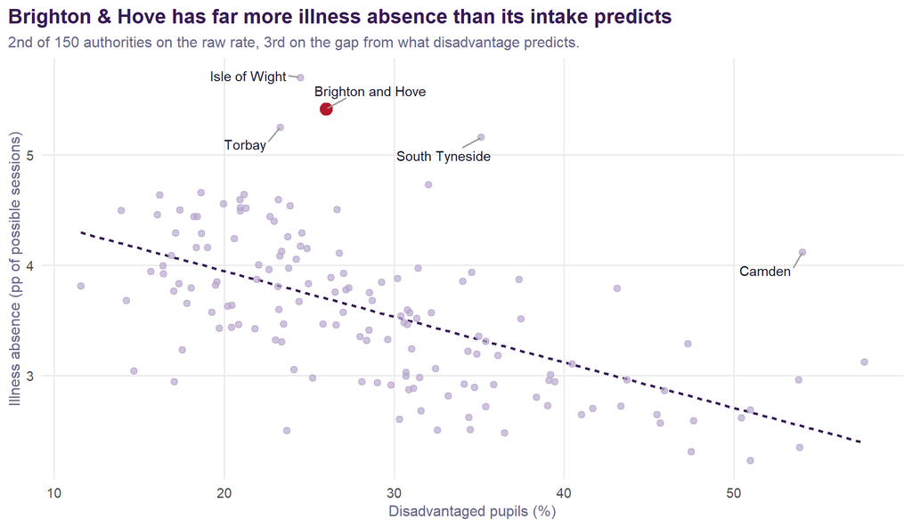

Figure 8: Illness-coded absence against disadvantage, local authorities with more than a million possible secondary sessions, 2025/26. The fitted line slopes DOWN: more disadvantaged authorities record less of their absence as illness.

On a disadvantage rate of 26.0%, the national relationship predicts illness absence of 3.70 points. The city posts 5.42 — **1.72 points above expectation**, the 3rd largest excess in the country.

The company it keeps is striking: Isle of Wight, Torbay, South Tyneside, Bristol, Plymouth. Coastal and peripheral authorities, several of them with the same mix of visible affluence and concentrated deprivation.

**NoteWhy this matters for reading any school’s attendance**

The coding gradient is a finding in its own right, and it cuts the same way as the main report’s argument about Attainment 8. A school in an affluent catchment and a school in a poor one can lose the same number of days and have those days recorded completely differently — one as illness, one as truancy. Any policy that targets *unauthorised* absence is therefore targeting poorer schools by construction, whether or not they are missing more school.

For Brighton & Hove, with its unusually sharp split between affluent and deprived catchments, that is worth knowing before anyone compares one of its schools with another on an authorised/unauthorised basis.

## 7.5 What “illness” is, and what it is not

This is where the data stops and the honest reading begins.

**Code I on the register means the school accepted the explanation given.** It covers a child with a chronic condition, a child with a heavy cold, a child whose anxiety makes the school gate impossible, and a child whose parent said “not well today” and was believed. The published data cannot separate them, and anyone who tells you it can is guessing.

**But the city is not simply authorising what other places refuse to.** That would be the obvious alternative explanation, and it does not hold: Brighton & Hove’s **unauthorised** absence is 2.42 points against England’s 2.35 — effectively identical, and 65th of 150 in the country. If schools here were re-labelling truancy as illness, the unauthorised figure would be *low*. It is average. The illness absence is **on top of** a normal amount of unauthorised absence, not instead of it.

**TipThe hypothesis worth testing**

The shape of this — a modest pre-pandemic gap that roughly tripled after 2020, concentrated in a code that covers anxiety as readily as influenza, in a city with well-documented adolescent mental health pressure — points at **emotionally based school avoidance** rather than at infectious disease.

That is a hypothesis, not a finding. This data cannot confirm it. But it is testable from records the council already holds, and it would be a far better use of the city’s analytical effort than counting suspensions.

# 8 What this does not show

Four honest limits, because the finding is only useful if it survives them.

**This is about suspension, not about the children suspended.** The claim here is about aggregates: suspension is a small share of total absence. For an individual child who is suspended repeatedly, the disruption is serious, the association with poor outcomes is severe, and nothing in this note argues otherwise. A policy aimed at the few hundred children in this city with repeat suspensions can be worth doing on its own merits while being irrelevant to the city’s attendance rate.

**Permanent exclusion does not appear in a school’s absence at all.** A permanently excluded pupil comes off the roll, so their subsequent absence belongs to alternative provision or to the next school. The figures above therefore understate exclusion’s total effect on attendance in the system — but permanent exclusion is running at 1 child a year across the whole of secondary Brighton & Hove, so the understatement is not large here.

**Nor do off-rolling or managed moves.** A pupil moved off a roll informally leaves no trace in either dataset. If the council’s real interest is in that, exclusions data is not where it will be found, and the school-level absence data will not find it either. This is a genuine gap and it is the one question in this area where the published data cannot answer the council.

**None of the models here identify a causal effect.** They establish that the association between suspension and non-suspension absence survives controls and shrinks dramatically under school fixed effects. They cannot rule out that some of what remains is causal. What they do rule out is that it is *large*.

# 9 What would be more use

If the council’s underlying concern is attendance — and on the evidence of *Pulling the Right Lever* it should be — then the published data points somewhere else entirely.

The decomposition in §7 has already named the target: **illness-coded absence**, which is 95% of everything that separates this city’s attendance from England’s. Persistent absence here sits at 27.2% of secondary pupils — more than one child in four missing at least a tenth of their schooling.

Four questions the council is far better placed to answer than I am, and which would each be worth more than a count of suspensions:

1. **Is the illness absence concentrated or spread?** The published data stops at the school. The council’s own returns would say whether this is a few hundred children missing a great deal or every child missing a little, and those are completely different problems with completely different responses.
2. **How much of it is anxiety rather than infection?** Code I does not distinguish them, but schools and GPs can. If a meaningful share of it is emotionally based school avoidance, the lever is mental health provision and reintegration support, and it sits with the council and the ICB rather than with headteachers.
3. **How far do they travel?** The city’s school system work shows disadvantaged children in Brighton & Hove travel further than their classmates, and longer journeys are associated with lower attendance. That is a lever the council controls directly, through catchments and admissions, and it has never been costed against attendance.
4. **What happens to attendance after a suspension?** If suspension really does start a spiral, this is where it would show up — in the council’s own attendance returns, not in any DfE publication. It would also be a far better argument for the council’s current interest than the aggregate one, which does not support it.

**ImportantThe one-line answer**

Exclusions matter to the children they happen to, and they are worth understanding on their own terms. As an explanation of Brighton & Hove’s attendance problem, they are **about 2% of it** — in a city that already suspends less than three-quarters of England while attending worse than all but a handful of local authorities in it.

If the city wants attendance to improve, exclusions are not where the work is. **Illness-coded absence is** — it is 95% of what separates Brighton & Hove from the rest of the country, and the city is 2nd worst in England on it.

Built 23 October 2026 from `R/15_exclusions.R`. Sources: DfE *Pupil absence in schools in England* (school level, autumn and spring terms, 2025/26); DfE *Suspensions and permanent exclusions in England* (school level, 2024/25); and this project’s school characteristics panel. All DfE data is Open Government Licence v3.0. No pupil-level data is used anywhere in this note.